# QTM 350 - Data Science Computing

Lecture 23 - Dependency Management, Virtual Environments, and Containers

Danilo Freire

danilo.freire@emory.edu

Emory University

20 November, 2024

# Hello again! 😊 How’s everything?

# Brief recap of last class 📚

## Parallel computing with Dask

- We discussed how to parallelise the training of machine learning models
- How to use automated machine learning (AutoML) tools to speed up the process
- We also discussed how to implement different methods to search for the best hyperparameters using TPOT, scikit-learn, and Dask
- Finally, we learnt about [Dask Clusters](https://docs.dask.org/en/latest/setup/clusters.html), which allow us to scale your computations across multiple cores or machines

[figure not shown]

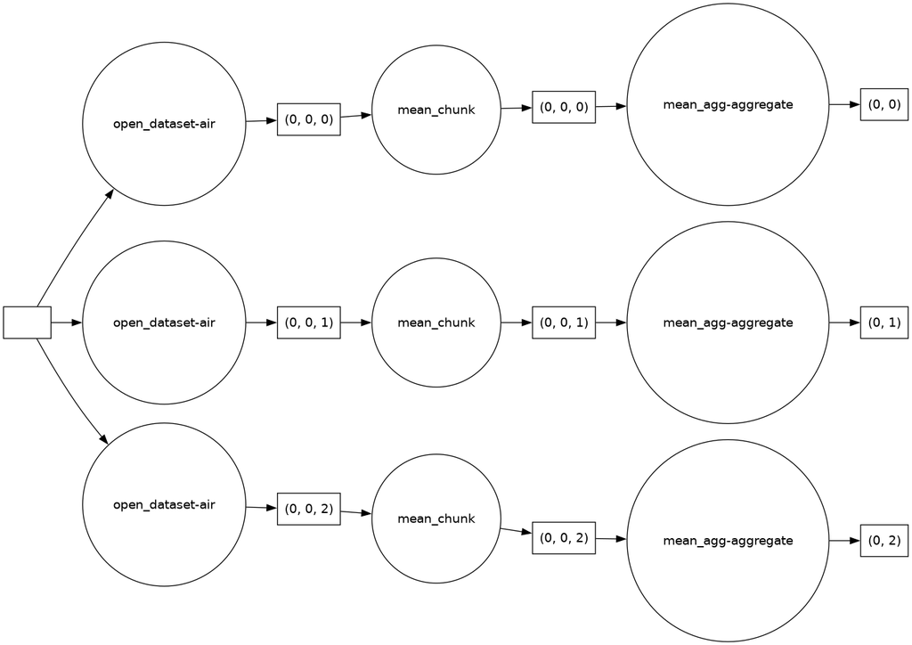

# Today’s agenda 📅

## Lecture outline

- Today we will talk about a different topic: how to make sure your results are reproducible?
- We will discuss the importance of dependency management, virtual environments, and containers
- Replication has been a recurring theme in this course, and today we will learn how to make it easier
- That is the main reason why we use the command line, git, Quarto, Jupyter, and other tools
- So today we will discuss some of the best practices to ensure computational reproducibility
- We will also discuss how to use containers to make your code portable, reproducible, and scalable
- Let’s get started! 🚀

[figure not shown]

[figure not shown]

# Dependency management 📦

## Congratulations! 🎉

- You now have a project!
- Your code works great, it runs pretty fast thanks to Dask, your Quarto reports are beautiful, and your analyses (all done in the command line) are stored in a well-documented GitHub repository
- Are you done? 🤔
- Not quite! 😅
- What if you need to run your code on a different machine? Or share it with a colleague? Or run it again in a few months?
- You need to make sure your code will run in the future, and that’s where dependency management comes in

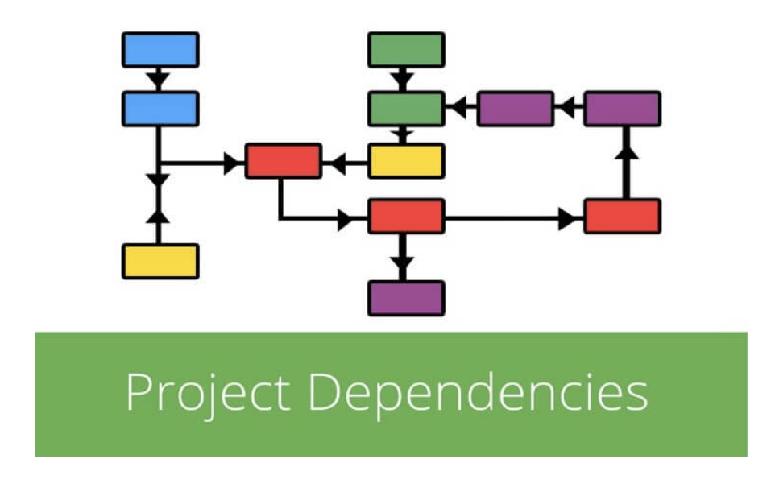

## Why do we need dependency management? 🤔

### The problem

- As we have seen in this course (and in many others), libraries and packages change constantly
- New versions are released, old versions are deprecated, and not all operating systems have the required libraries installed to run your code
- Even extremely simple code can break from one version of a library to the next
- this code written in Python 2.7:

```python
print "Hello, world!"
```

- will not work in Python 3.x

```python
print "Hello world!"
```

```
  File "/var/folders/96/r1yycxlj28958p1cdynhbyzw0000gn/T/Rtmpa0OGSM/chunk-code-b08d2b78904b.txt", line 1
    print "Hello world!"
                       ^
SyntaxError: Missing parentheses in call to 'print'. Did you mean print("Hello world!")?
```

### Some definitions

- Dependency management is the process of ensuring that your code will run in the future
- Dependencies are the external components necessary to run your code, such as libraries, packages, and software
- Packages have a name, a type, a version, relevant files for the package’s functionality, and potentially dependencies on other packages
- A package registry is a directory for packages and stores metadata about packages in the registry, such as [CRAN](https://cran.r-project.org/), [PyPI](https://pypi.org/), or [Conda](https://docs.conda.io/en/latest/)
- Dependency management tools help you manage your dependencies, such as [pip](https://pip.pypa.io/en/stable/) and [conda](https://docs.conda.io/en/latest/)

## The reproducibility crisis 🚨

- We have already seen how important it is to ensure that your results are reproducible
- The reproducibility crisis is a term used to describe the inability of researchers to replicate the results of a study
- This affects computer science, statistics, and many other fields
- Apart from statistical issues such as p-hacking, publication bias, and low statistical power, one of the main reasons for the reproducibility crisis is the lack of proper documentation and dependency management
- While the statistical problems are a bit more complex, the latter can be easily solved with tools that we already have at our disposal
- According to a recent [Nature survey](https://www.nature.com/articles/533452a), more than 70% of researchers have tried and failed to reproduce another scientist’s experiments, and more than half have failed to reproduce their own experiments 😳
- 90% of researchers believe that there is a reproducibility crisis in science

[figure not shown]

## The reproducibility trade-off 🔄

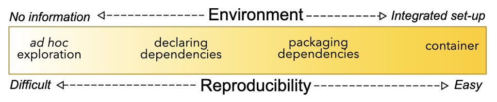

- How far should we go to ensure that our results are reproducible?
- Due diligence starts at declaring dependencies
- You can empower your declared dependencies with a package/environment manager such as `conda` or `pip`
- Packaging dependencies uses tools like `renv` (for R), or `pipenv` (for Python)
- Online environments can be created for your work (in a relatively user friendly way), such as [Code Ocean](https://codeocean.com/) ($$$), or [Binder](https://mybinder.org/) (free, but with several limitations as we will see)
- Containers are awesome, and container tools like [Docker](https://www.docker.com/) and [Singularity](https://sylabs.io/singularity/) can be used to package your code and dependencies in a portable way
- Which one should you use? It depends on your needs, but the more you do, the more reproducible your work should be!

[Containers](https://raw.githack.com/danilofreire/qtm350/main/lectures/lecture-23/23-containers.html)